# team

Adam Brandt

9/10/2020

**Reading the Data:**

```r
choco <- read.csv("https://raw.githubusercontent.com/xdaiISU/ds202materials/master/hwlabs/data/choco.csv")
str(choco)
```

```
## 'data.frame':    2312 obs. of  13 variables:
##  $ REF                 : int  2454 2458 2454 797 797 1015 1019 1011 1019 1011 ...
##  $ Company             : chr  "5150" "5150" "5150" "A. Morin" ...
##  $ Location            : chr  "U.S.A." "U.S.A." "U.S.A." "France" ...
##  $ Date                : int  2019 2019 2019 2012 2012 2013 2013 2013 2013 2013 ...
##  $ Bean_Origin         : chr  "Madagascar" "Dominican Republic" "Tanzania" "Peru" ...
##  $ Specific_Bean_Origin: chr  "Bejofo Estate, batch 1" "Zorzal, batch 1" "Kokoa Kamili, batch 1" "Peru" ...
##  $ Cocoa_Percent       : num  76 76 76 63 70 70 63 70 70 70 ...
##  $ Ingredients         : chr  "3- B,S,C" "3- B,S,C" "3- B,S,C" "4- B,S,C,L" ...
##  $ Characteristics1    : chr  "cocoa" "cocoa" "rich cocoa" "fruity" ...
##  $ Characteristics2    : chr  "blackberry" "vegetal" "fatty" "melon" ...
##  $ Characteristics3    : chr  "full body" "savory" "bready" "roasty" ...
##  $ Characteristics4    : chr  NA NA NA NA ...
##  $ Rating              : num  3.75 3.5 3.25 3.75 3.5 4 4 3.75 3.5 3.25 ...
```

5. Brainstorm two analyses you would like to perform with your teammate. Describe in plain language what comparisons are you making. Create suitable numerical and graphical summaries for your analyses. Describe the results.

**Adam Brandt**

**Chocolate Rating by Location**

I wanted to see which location has the most high rated chocolate and which location has the lowest rated chocolate.

```r
GoodLoc <- choco[(choco$Rating >= 4) , ]
sort(GoodLoc$Location)
```

```
##   [1] "Australia"   "Australia"   "Australia"   "Australia"   "Belgium"
##   [6] "Belgium"     "Belgium"     "Belgium"     "Belgium"     "Brazil"
##  [11] "Canada"      "Canada"      "Canada"      "Canada"      "Canada"
##  [16] "Canada"      "Canada"      "Canada"      "Canada"      "Canada"
##  [21] "Canada"      "Canada"      "Canada"      "Denmark"     "Denmark"
##  [26] "Ecuador"     "Ecuador"     "Ecuador"     "France"      "France"
##  [31] "France"      "France"      "France"      "France"      "France"
##  [36] "France"      "France"      "France"      "France"      "France"
##  [41] "France"      "France"      "France"      "France"      "France"
##  [46] "Germany"     "Guatemala"   "Italy"       "Italy"       "Italy"
##  [51] "Italy"       "Madagascar"  "Scotland"    "Spain"       "Spain"
##  [56] "Spain"       "Switzerland" "Switzerland" "Switzerland" "Switzerland"
##  [61] "Switzerland" "Switzerland" "U.K."        "U.K."        "U.K."
##  [66] "U.K."        "U.S.A."      "U.S.A."      "U.S.A."      "U.S.A."
##  [71] "U.S.A."      "U.S.A."      "U.S.A."      "U.S.A."      "U.S.A."
##  [76] "U.S.A."      "U.S.A."      "U.S.A."      "U.S.A."      "U.S.A."
##  [81] "U.S.A."      "U.S.A."      "U.S.A."      "U.S.A."      "U.S.A."
##  [86] "U.S.A."      "U.S.A."      "U.S.A."      "U.S.A."      "U.S.A."
##  [91] "U.S.A."      "U.S.A."      "U.S.A."      "U.S.A."      "U.S.A."
##  [96] "U.S.A."      "U.S.A."      "U.S.A."      "U.S.A."      "U.S.A."
## [101] "U.S.A."      "U.S.A."
```

```r
BadLoc <- choco[(choco$Rating <= 1) , ]
sort(BadLoc$Location)
```

```
## [1] "Belgium"  "Belgium"  "Belgium"  "Sao Tome"
```

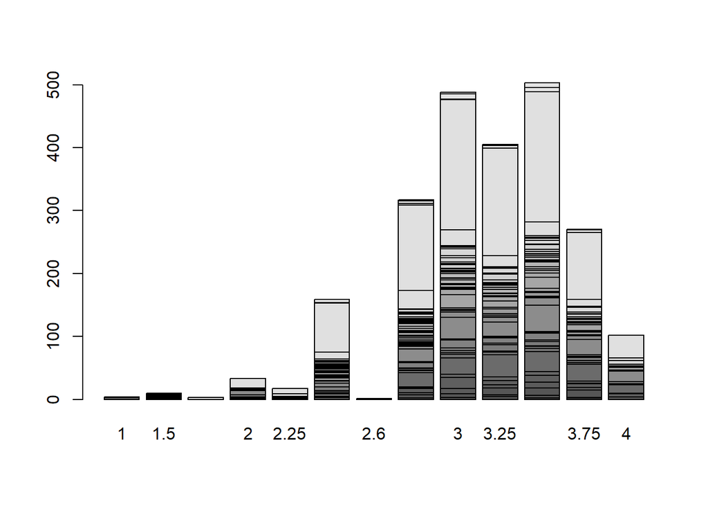

```r
barplot(table(choco$Location, choco$Rating))
```

The lowest rated chocolate comes from Belgium and the country with the most high rated chocolate is the U.S.A.

**Lisa McDaniel**

**USA Chocolate**

I got the summary statistics for the dataset and saw that there are 2312 records. I filtered the original data to include only those records where the *Location* was *U.S.A* and stored the 966 records in USAchoch. I further filtered the data to include only those records where the *Bean Origin* was also in the *U.S.A and stored the 28 records in USAbean. I got the summary statistics for USABean and created plots showing the number of ratings per yeary and by cocoa percentage.

Ratings began in 2006 but have not been yearly. Ratings peaked in 2012, 2013 and 2014 and have remained pretty steady over the past few years.

```
##       REF         Company            Location              Date
##  Min.   :   5   Length:2312        Length:2312        Min.   :2006
##  1st Qu.: 741   Class :character   Class :character   1st Qu.:2011
##  Median :1351   Mode  :character   Mode  :character   Median :2014
##  Mean   :1318                                         Mean   :2014
##  3rd Qu.:1912                                         3rd Qu.:2016
##  Max.   :2490                                         Max.   :2020
##  Bean_Origin        Specific_Bean_Origin Cocoa_Percent    Ingredients
##  Length:2312        Length:2312          Min.   : 42.00   Length:2312
##  Class :character   Class :character     1st Qu.: 70.00   Class :character
##  Mode  :character   Mode  :character     Median : 70.00   Mode  :character
##                                          Mean   : 71.65
##                                          3rd Qu.: 75.00
##                                          Max.   :100.00
##  Characteristics1   Characteristics2   Characteristics3   Characteristics4
##  Length:2312        Length:2312        Length:2312        Length:2312
##  Class :character   Class :character   Class :character   Class :character
##  Mode  :character   Mode  :character   Mode  :character   Mode  :character
##
##
##
##      Rating
##  Min.   :1.000
##  1st Qu.:3.000
##  Median :3.250
##  Mean   :3.184
##  3rd Qu.:3.500
##  Max.   :4.000
```

```
##       REF         Company            Location              Date
##  Min.   :  24   Length:28          Length:28          Min.   :2006
##  1st Qu.: 719   Class :character   Class :character   1st Qu.:2011
##  Median :1048   Mode  :character   Mode  :character   Median :2013
##  Mean   :1055                                         Mean   :2013
##  3rd Qu.:1371                                         3rd Qu.:2014
##  Max.   :2482                                         Max.   :2020
##  Bean_Origin        Specific_Bean_Origin Cocoa_Percent   Ingredients
##  Length:28          Length:28            Min.   :55.00   Length:28
##  Class :character   Class :character     1st Qu.:69.25   Class :character
##  Mode  :character   Mode  :character     Median :70.00   Mode  :character
##                                          Mean   :69.25
##                                          3rd Qu.:72.00
##                                          Max.   :85.00
##  Characteristics1   Characteristics2   Characteristics3   Characteristics4
##  Length:28          Length:28          Length:28          Length:28
##  Class :character   Class :character   Class :character   Class :character
##  Mode  :character   Mode  :character   Mode  :character   Mode  :character
##
##
##
##      Rating
##  Min.   :2.000
##  1st Qu.:3.000
##  Median :3.250
##  Mean   :3.196
##  3rd Qu.:3.500
##  Max.   :3.750
```

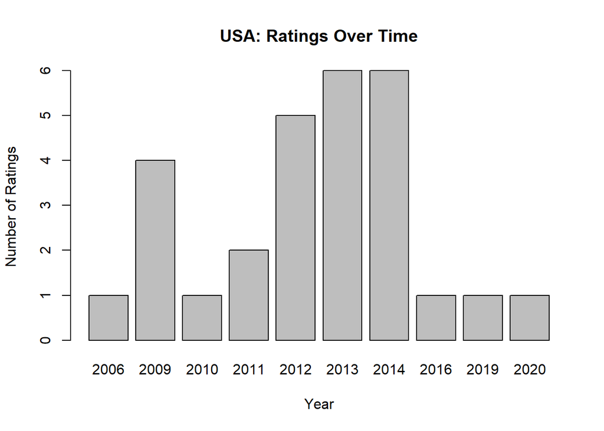

The most commonly rated chocolate has a cocoa percentage of 70%, followed by 72%.

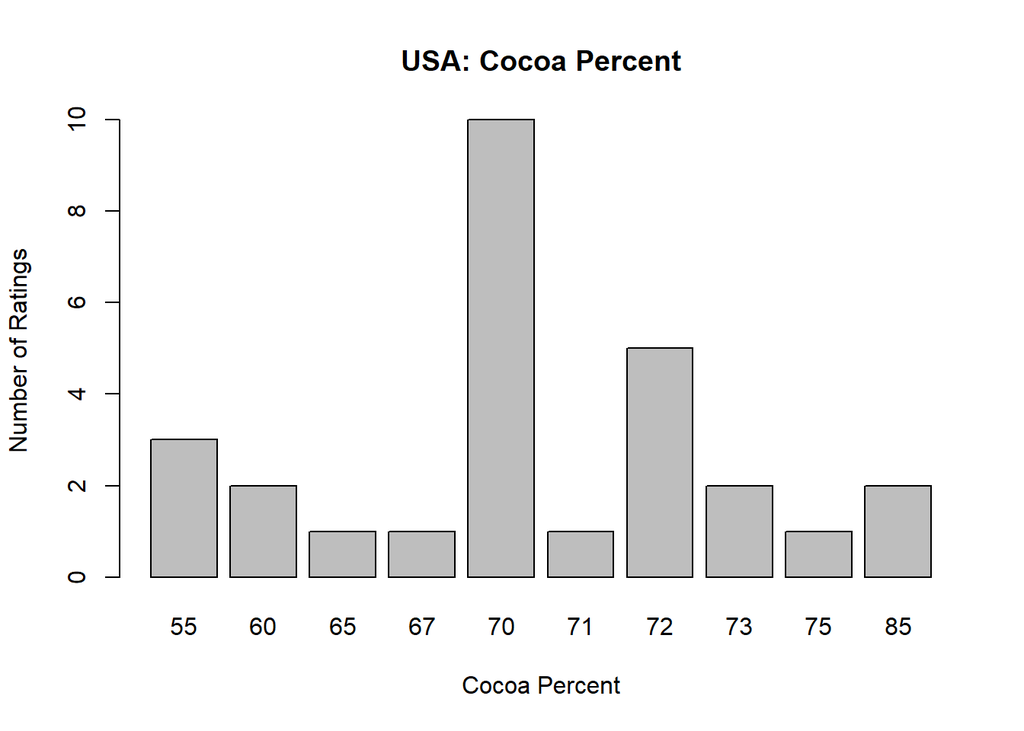

Created box plots to show the ratings per cocoa percentage. Chocolate with 67% and 75% have the most favorable rating of 3.75.

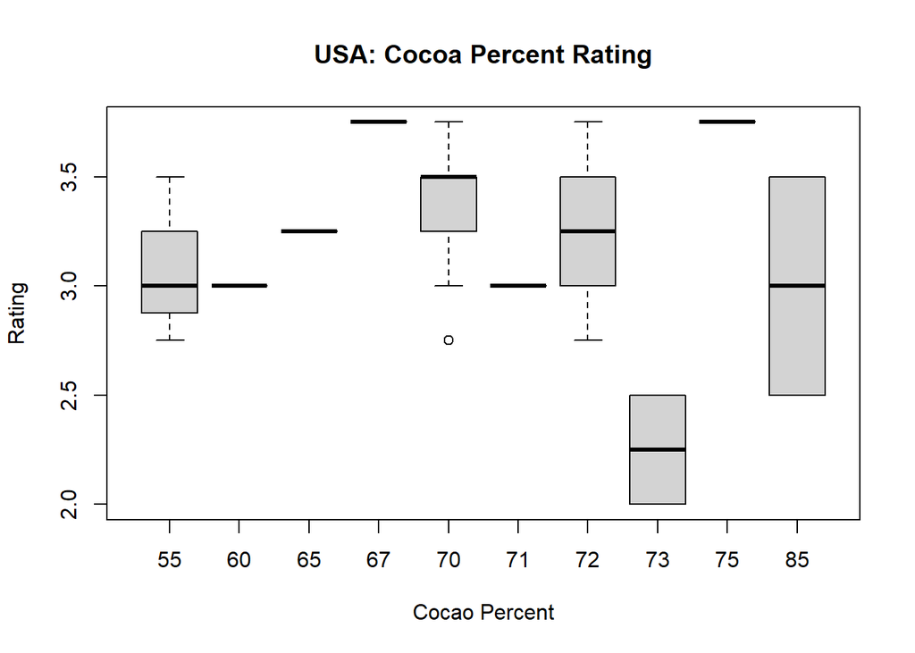